# Reproducible Research: Peer Assessment 1

## Imputing missing values

### 1. Calculate and report the total number of missing values in the dataset (i.e. the total number of rows with NAs)

```r
NumberNAs <- nrow(Dataset[!complete.cases(Dataset),])
print(NumberNAs)
```

```
## [1] 2304
```

### 2. Devise a strategy for filling in all of the missing values in the dataset. The strategy does not need to be sophisticated. For example, you could use the mean/median for that day, or the mean for that 5-minute interval, etc.

We will use the mean for that 5-minute interval (*meansteps* column) to fill the NAs. First we will merge the original *Dataset* data frame with the *MeanbyInterval* data frame by the *interval* column so we can add a new column *meansteps*. Then, we will replace the NAs value of the *steps* column with the value in *meansteps*. Finally we will remove the *meansteps* column

### 3. Create a new dataset that is equal to the original dataset but with the missing data filled in.

```r
## merge original dataset with means by interval dataset
DatasetFilled <- merge(Dataset, MeanbyIntervalOmitNAs, by='interval', suffixes = c('','.y'))

## Select rounded value to whole number of steps if value is
DatasetFilled[is.na(DatasetFilled$steps),'steps'] <- round(DatasetFilled[is.na(DatasetFilled$steps), 'meansteps'],0)

## Remove meansteps column
DatasetFilled <- DatasetFilled[, 1:3]

## Check there are not NAs
nrow(DatasetFilled[!complete.cases(DatasetFilled),])
```

```
## [1] 0
```

### 4. Make a histogram of the total number of steps taken each day and Calculate and report the mean and median total number of steps taken per day. Do these values differ from the estimates from the first part of the assignment? What is the impact of imputing missing data on the estimates of the total daily number of steps?

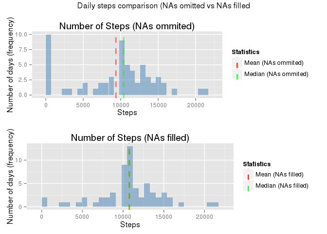

```r
## Calculate new values for number of daily steps
StepsbyDayFilled <- aggregate(DatasetFilled$steps, by=list(day=DatasetFilled$date), FUN=sum, na.rm=TRUE)
names(StepsbyDayFilled)[2] <- 'steps'

## Calculate values for the median and the mean with NAs filled
MedianFilled <- round(median(StepsbyDayFilled$steps),2)
MeanFilled <- round(mean(StepsbyDayFilled$steps),2)

plot2 <- ggplot(data=StepsbyDayFilled, aes(StepsbyDayFilled$steps)) +
        geom_histogram(fill='steelblue', alpha=0.5, binwidth=700) +
        labs(x = 'Steps', y = 'Number of days (frequency)', title = 'Number of Steps (NAs filled)') +
        geom_vline(aes(xintercept=MeanFilled, color='Mean (NAs filled)'),
               linetype='dashed', size=1, alpha=0.5, show_guide=TRUE) +
        geom_vline(aes(xintercept=MedianFilled, color='Median (NAs filled)'),
               linetype='dashed', size=1, alpha=0.5, show_guide=TRUE) +
        scale_color_manual('Statistics', values = c('Mean (NAs filled)' = 'red', 'Median (NAs filled)' = 'green'))

## Print both histograms to compare the impact of imputing missing data
library(grid)
library(gridExtra)
grid.arrange(plot1, plot2, top = "Daily steps comparison (NAs omitted vs NAs filled")
```

```r
## Print mean and median calculated from filled dataset
print(MedianFilled)
```

```
## [1] 10762
```

```r
print(MeanFilled)
```

```
## [1] 10765.64
```

As we can see in the graphs mean and median calculated from the dataset with the missing values filled with our stimation get closer values near the median of the original dataset.

## Are there differences in activity patterns between weekdays and weekends?

### 1. Create a new factor variable in the dataset with two levels – “weekday” and “weekend” indicating whether a given date is a weekday or weekend day.

We will use the dataset with the missing values filled for this part of the assignment.

```r
## Backup locale time settings
temp <- Sys.getlocale("LC_TIME")

## Set locale time settings to English GB
Sys.setlocale("LC_TIME","en_GB.UTF-8")
```

```
## [1] "en_GB.UTF-8"
```

```r
## New column with the value of weekday for the Dataset
DatasetFilled$weekday <- weekdays(as.Date(DatasetFilled[,'date']))

## if the weekday is Saturday or Sunday, we change the value to weekend
DatasetFilled[DatasetFilled$weekday %in% c('Saturday','Sunday'),'weekday'] <- 'weekend'

## if the weekday is not weekend we change the value to weekday
DatasetFilled[!(DatasetFilled$weekday=='weekend'),'weekday'] <- 'weekday'

## weekday needs to be a factor variable
DatasetFilled$weekday <- as.factor(DatasetFilled$weekday)

## switch back locale to initial value
Sys.setlocale("LC_TIME",temp)
```

```
## [1] "en_US.UTF-8"
```

```r
## print the structure of the dataset
str(DatasetFilled)
```

```
## 'data.frame':    17568 obs. of  4 variables:
##  $ interval: Factor w/ 288 levels "0","10","100",..: 1 1 1 1 1 1 1 1 1 1 ...
##  $ steps   : num  2 0 0 0 0 0 0 0 0 0 ...
##  $ date    : Factor w/ 61 levels "2012-10-01","2012-10-02",..: 1 54 28 37 55 46 20 47 38 56 ...
##  $ weekday : Factor w/ 2 levels "weekday","weekend": 1 1 2 1 2 1 2 1 1 2 ...
```

### 2. Make a panel plot containing a time series plot (i.e. type = “l”) of the 5-minute interval (x-axis) and the average number of steps taken, averaged across all weekday days or weekend days (y-axis). See the README file in the GitHub repository to see an example of what this plot should look like using simulated data.

The following plot represents the different pattern of the activity between weekdays and weekends

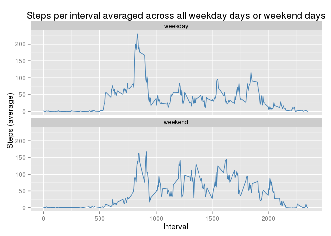

```r
## Agregate steps by interval calculating the average by interval and weekday type value and ignoring missing values
MeanbyIntervalFilledWeekday <- aggregate(DatasetFilled$steps, by=list(interval=DatasetFilled$interval, weekday=DatasetFilled$weekday), FUN=mean, na.rm=TRUE)
names(MeanbyIntervalFilledWeekday)[3] <- 'meansteps'

## Order the dataset by interval
MeanbyIntervalFilledWeekday <- MeanbyIntervalFilledWeekday[order(as.numeric(as.character(MeanbyIntervalFilledWeekday$interval))),]

## print a line plot faceted by weekday type
plot <- ggplot(data=MeanbyIntervalFilledWeekday, aes(x=as.numeric(as.character(interval)), y=meansteps)) +
    geom_line(color='steelblue') +
    labs(x = "Interval", y = "Steps (average)", title = "Steps per interval averaged across all weekday days or weekend days") +
    facet_wrap(~ weekday, nrow=2)
print(plot)
```